# An attempt to combine DE and DM data in the Adenoid Cystic Carcinoma

## Alexander Favorov

### 18 Jun 2014

Each de gene is charaterised by the probability to be DE (PPDE). Lets's compare the value for the genes in the dm.and.de intersection and for the other genes.

# gene lists for flanks 1000 around intevals with fdr<0.1

1372 genes in dm;

3761 genes in de;

149 in de.and.dm

### DE vs DM

Comparing the probability of DE for DM genes and for all the non-DM DE genes.

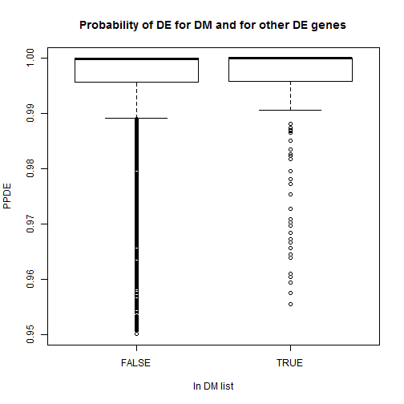

The Wilcoxon test does not show significant difference (p-value=0.898)

The same for fold DE change (PostFC)

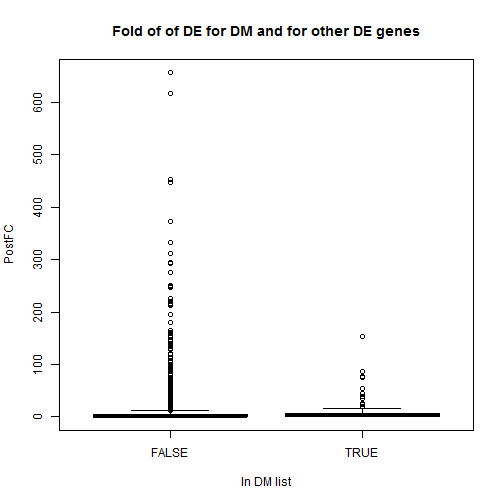

The Wilcoxon test does not show significant difference (p-value=0.2996)

### DM vs DE

Each dm gene is charaterised by the p-value (the closer to 0, the more oprobable is DM). Lets's compare the value for the genes in the dm.and.de intersection and for the other genes.

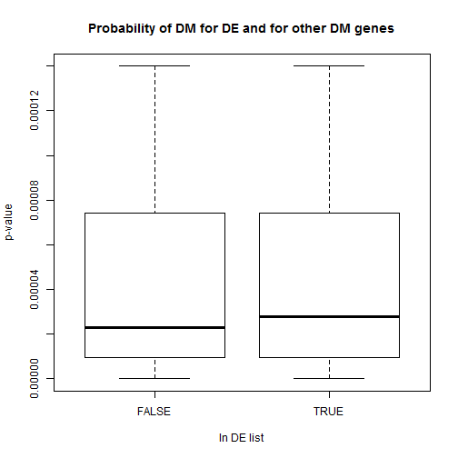

Not significant, again (p-value=0.2898)

### Direction of DE and DM

Let's test whether the directions of de and dm are consistent.

```
##             dm.direction
## de.direction FALSE TRUE
##        FALSE    35   31
##        TRUE     41   41
```

No correcpondence, looks like completely random Fisher table.

# DM gene lists for flanks 100000 around intevals with fdr<0.1

7378 genes in dm;

3761 genes in de;

### DE vs DM

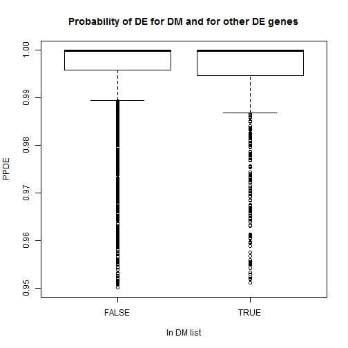

The Wilcoxon test does not show significant difference (p-value=0.2667)

The same for fold DE change (PostFC)

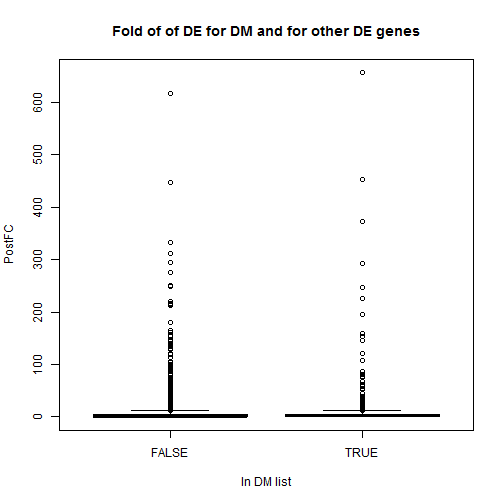

### DM vs DE

Each dm gene is charaterised by the p-value (the closer to 0, the more oprobable is DM). Lets's compare the value for the genes in the dm.and.de intersection and for the other genes.

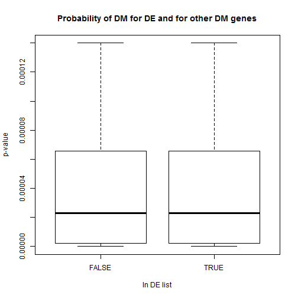

Not significant, again (p-value=0.8183)

### Direction of DE and DM

Let's test whether the directions of de and dm are consistent.

```
##             dm.direction
## de.direction FALSE TRUE
##        FALSE   193  123
##        TRUE    192  185
```

# DM gene lists for no flanks; intevals with fdr<0.1

127 genes in dm;

3761 genes in de;

18 in de.and.dm

### DE vs DM

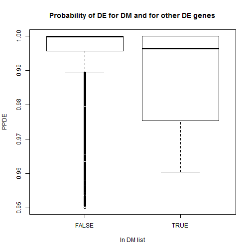

The Wilcoxon test does not show significant difference (p-value=0.1394)

The same for fold DE change (PostFC)

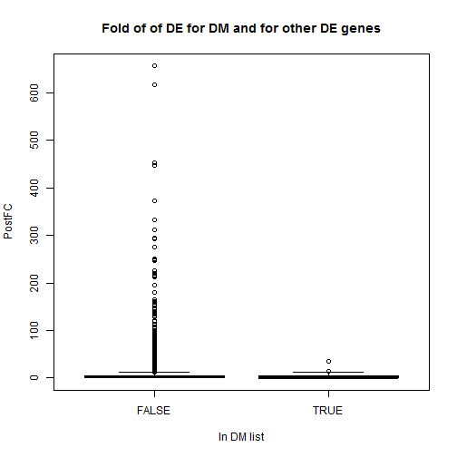

The Wilcoxon test does not show significant difference (p-value=0.558)

### DM vs DE

Each dm gene is charaterised by the p-value (the closer to 0, the more oprobable is DM). Lets's compare the value for the genes in the dm.and.de intersection and for the other genes.

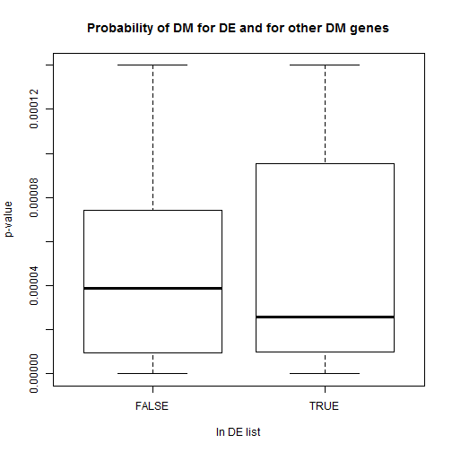

Not significant, again (p-value=0.8707)

### Direction of DE and DM

Let's test whether the directions of de and dm are consistent.

```
##             dm.direction
## de.direction FALSE TRUE
##        FALSE     4    5
##        TRUE      2    7
```

No correspondence, looks like completely random Fisher table.

# DM gene lists for flanks 100000 around intevals with bonferroni-corrected DM intervals

194 genes in dm;

3761 genes in de;

29 in de.and.dm

### DE vs DM

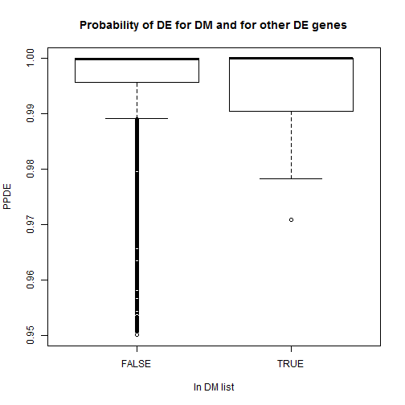

The Wilcoxon test does not show significant difference (p-value=0.6705)

The same for fold DE change (PostFC)

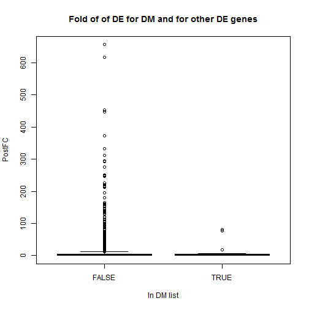

The Wilcoxon test does not show significant difference (p-value=0.3618)

### DM vs DE

Each dm gene is charaterised by the p-value (the closer to 0, the more oprobable is DM). Lets's compare the value for the genes in the dm.and.de intersection and for the other genes.

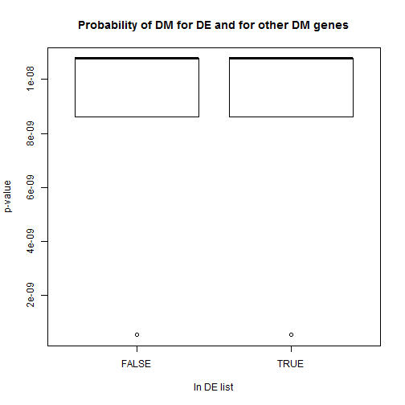

Not significant, again (p-value=0.6027)

### Direction of DE and DM

Let's test whether the directions of de and dm are consistent.

```
##             dm.direction
## de.direction FALSE TRUE
##        FALSE    12    2
##        TRUE     13    2
```

No correspondence, looks like completely random Fisher table.

# DM gene lists for flanks 1000000 around intevals with bonferroni-corrected DM intervals

1616 genes in dm;

3761 genes in de;

173 in de.and.dm

### DE vs DM

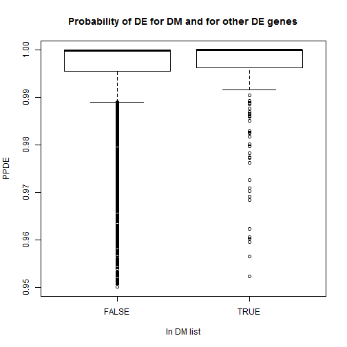

The Wilcoxon test does not show significant difference (p-value=0.3704)

The same for fold DE change (PostFC)

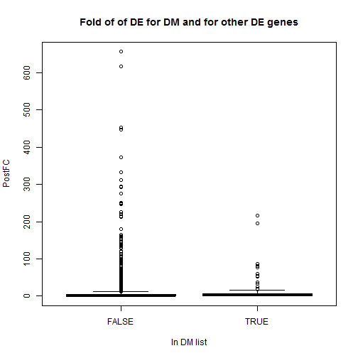

### DM vs DE

Each dm gene is charaterised by the p-value (the closer to 0, the more oprobable is DM). Lets's compare the value for the genes in the dm.and.de intersection and for the other genes.

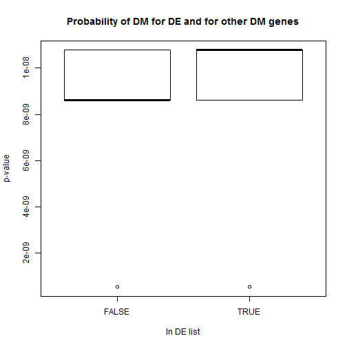

Not significant, again (p-value=0.3085)

### Direction of DE and DM

Let's test whether the directions of de and dm are consistent.

```
##             dm.direction
## de.direction FALSE TRUE
##        FALSE    63    9
##        TRUE     84   17
```

No correspondence, looks like completely random Fisher table.

# gene lists for flanks 1000 around intevals with fdr<0.1 ; differectial expressio with PPDE>0.999

1372 genes in dm;

2424 genes in de;

96 in de.and.dm

### DE vs DM

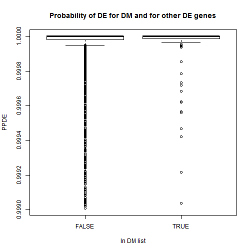

The Wilcoxon test does not show significant difference (p-value=0.878)

The same for fold DE change (PostFC)

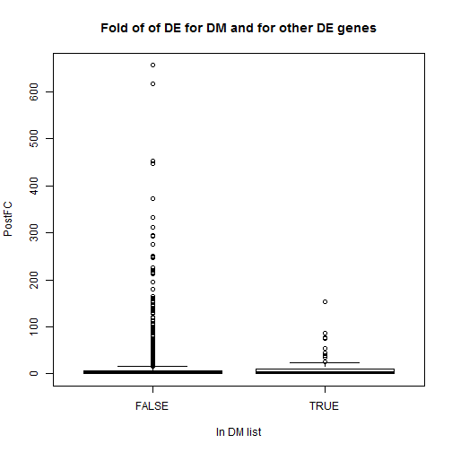

The Wilcoxon test does not show significant difference (p-value=0.6079)

### DM vs DE

Each dm gene is charaterised by the p-value (the closer to 0, the more oprobable is DM). Lets's compare the value for the genes in the dm.and.de intersection and for the other genes.

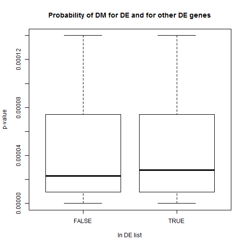

Not significant, again (p-value=0.505)

### Direction of DE and DM

Let's test whether the directions of de and dm are consistent.

```
##             dm.direction
## de.direction FALSE TRUE
##        FALSE    26   19
##        TRUE     28   22
```

No correspondence, looks like completely random Fisher table.